# Introduction to Deep Learning - Week 6 - Final Project

## University of Colorado Boulder

## Table of content

- Introduction
- Libraries Import
- EDA
- Models
- Summary
- References
- Citation

## Introduction

The Fruits-360 dataset is a large collection of images of multiple fruits, vegetables and nuts. With over 94,000 images, this dataset has been designed to help researchers and developers in fields like computer vision and machine learning.

It includes 141 different classes of produce, such as apples, bananas, tomatoes, and much more.

In this dataset, each image is carefully captured at a size of 100x100 pixels. The images are organized into a training set of 70,491 images and a test set of 23,619 images.

The images were filmed using a special setup that involved rotating the fruits in front of a camera to create a clear view of each item. This process, along with an algorithm to improve image quality, ensures that the fruits are shown in a consistent way.

**I'm trying to solve the following problem:** Build a model that will classify fruits, vegetables and nuts.

GitHub link https://github.com/ammarhameed/DTSA-5511

Dataset link https://www.kaggle.com/datasets/moltean/fruits/data

## Libraries Import

```python
import numpy as np
import os
import matplotlib.pyplot as plt
import random
import seaborn as sns
from PIL import Image
import pandas as pd
from tensorflow.keras.preprocessing import image
import tensorflow as tf
from tensorflow.keras.applications import MobileNetV2
from tensorflow.keras.layers import GlobalAveragePooling2D
from tensorflow.keras.layers import Conv2D, Flatten
from tensorflow.keras.layers import Conv2D, MaxPooling2D, BatchNormalization
from tensorflow.keras.applications import ResNet50
from tensorflow.keras.models import Sequential
from tensorflow.keras.layers import Dense, Dropout, Input
from tensorflow.keras.preprocessing.image import ImageDataGenerator
from sklearn.model_selection import train_test_split
```

```python
# I'm setting the dirs here, please note that if you are using another path make sure to change the below to reflect what you have
train_dir = 'fruits/fruits-360_dataset_100x100/fruits-360/Training'
test_dir = 'fruits/fruits-360_dataset_100x100/fruits-360/Test'
```

# EDA

util functions

```python
def load_data(directory):
    data = []
    for class_name in os.listdir(directory):
        class_dir = os.path.join(directory, class_name)
        if os.path.isdir(class_dir):
            for filename in os.listdir(class_dir):
                if filename.endswith('.jpg'):
                    data.append({
                        'filename': filename,
                        'class': class_name
                    })
    return pd.DataFrame(data)
```

```python
train_data = load_data(train_dir)
test_data = load_data(test_dir)

print("Training Data:")
print(train_data.info())
print("\nTest Data:")
print(test_data.info())
```

```
Training Data:
<class 'pandas.core.frame.DataFrame'>
RangeIndex: 70491 entries, 0 to 70490
Data columns (total 2 columns):
 #   Column    Non-Null Count  Dtype
---  ------    --------------  -----
 0   filename  70491 non-null  object
 1   class     70491 non-null  object
dtypes: object(2)
memory usage: 1.1+ MB
None

Test Data:
<class 'pandas.core.frame.DataFrame'>
RangeIndex: 23619 entries, 0 to 23618
Data columns (total 2 columns):
 #   Column    Non-Null Count  Dtype
---  ------    --------------  -----
 0   filename  23619 non-null  object
 1   class     23619 non-null  object
dtypes: object(2)
memory usage: 369.2+ KB
None
```

### Visualization

Let's visualize the dataset

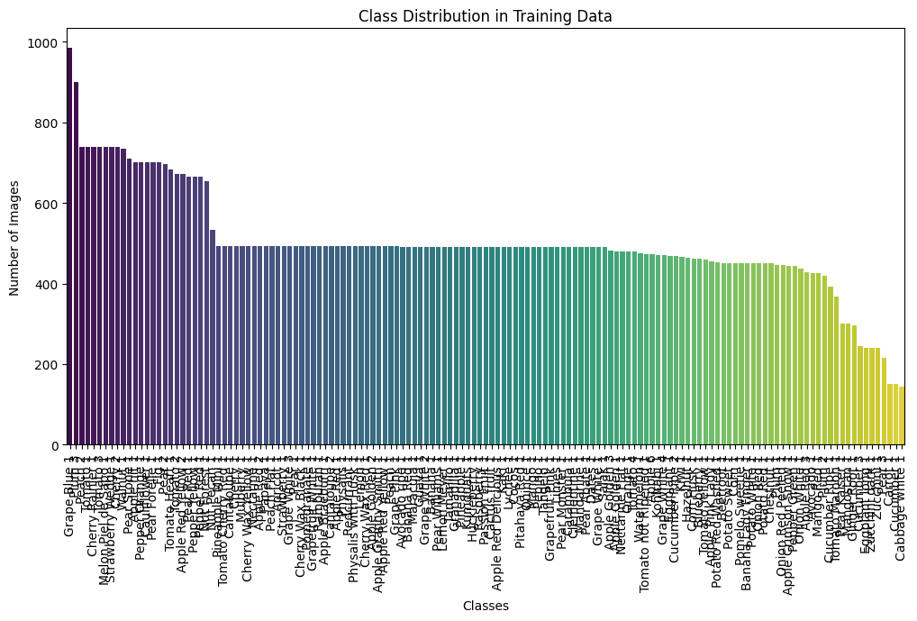

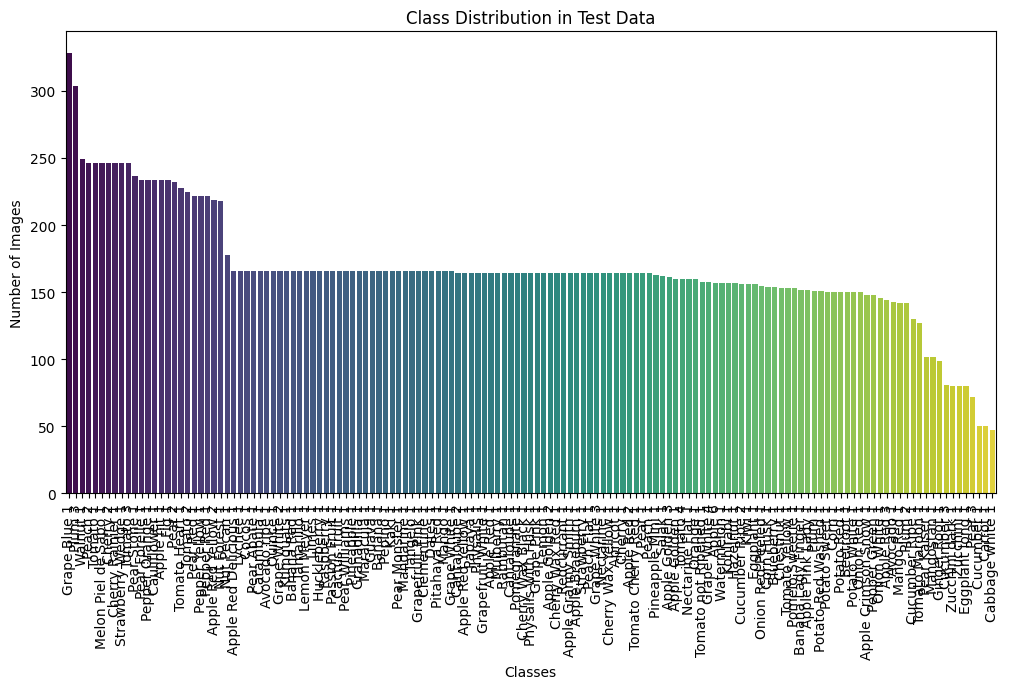

```python
train_class_counts = train_data['class'].value_counts()
test_class_counts = test_data['class'].value_counts()

plt.figure(figsize=(12, 6))
sns.barplot(x=train_class_counts.index, y=train_class_counts.values, hue=train_class_counts.index, palette='viridis', legend=False)
plt.title('Class Distribution in Training Data')
plt.xticks(rotation=90)
plt.xlabel('Classes')
plt.ylabel('Number of Images')
plt.show()

plt.figure(figsize=(12, 6))
sns.barplot(x=test_class_counts.index, y=test_class_counts.values, hue=test_class_counts.index, palette='viridis', legend=False)
plt.title('Class Distribution in Test Data')
plt.xticks(rotation=90)
plt.xlabel('Classes')
plt.ylabel('Number of Images')
plt.show()
```

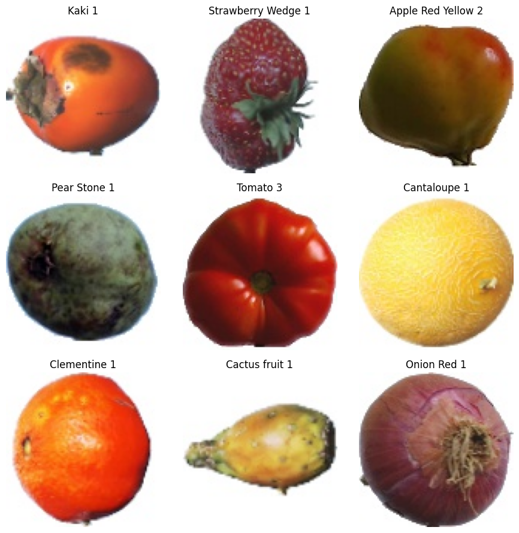

```python
sample_images = train_data.sample(9, random_state=1)
plt.figure(figsize=(9, 9))
for i, row in enumerate(sample_images.itertuples(), 1):
    img_path = os.path.join(train_dir, row[2], row.filename)
    img = plt.imread(img_path)
    plt.subplot(3, 3, i)
    plt.imshow(img)
    plt.title(row[2])
    plt.axis('off')
plt.tight_layout()
plt.show()
```

```python
total_images = len(train_data) + len(test_data)
print(f"\nTotal number of images in the dataset: {total_images}")

num_classes = train_data['class'].nunique()
print(f"Number of unique classes: {num_classes}")

image_size = (100, 100)
print(f"Image Size: {image_size}")
```

```
Total number of images in the dataset: 94110
Number of unique classes: 141
Image Size: (100, 100)
```

# Models

```python
datagen = ImageDataGenerator(rescale=1./255, validation_split=0.2)
train_generator = datagen.flow_from_directory(
    'fruits/fruits-360_dataset_100x100/fruits-360/Training',
    target_size=(100, 100),
    batch_size=32,
    class_mode='sparse',
    subset='training'
)
validation_generator = datagen.flow_from_directory(
    'fruits/fruits-360_dataset_100x100/fruits-360/Test',
    target_size=(100, 100),
    batch_size=32,
    class_mode='sparse',
    subset='validation'
)
```

```
Found 56432 images belonging to 141 classes.
Found 4665 images belonging to 141 classes.
```

### First CNN Model

```python
def create_cnn_model():
    model = Sequential()

    model.add(Input(shape=(100, 100, 3)))

    # Conv 1
    model.add(Conv2D(32, (3, 3), activation='relu'))
    model.add(MaxPooling2D(pool_size=(2, 2)))

    # Conv 2
    model.add(Conv2D(64, (3, 3), activation='relu'))
    model.add(MaxPooling2D(pool_size=(2, 2)))

    # Conv 3
    model.add(Conv2D(128, (3, 3), activation='relu'))
    model.add(MaxPooling2D(pool_size=(2, 2)))

    # Flatten
    model.add(Flatten())

    # FC Layer
    model.add(Dense(128, activation='relu'))
    model.add(Dropout(0.5))
    model.add(Dense(141, activation='softmax'))

    return model

model = create_cnn_model()

model.compile(optimizer='adam', loss='sparse_categorical_crossentropy', metrics=['accuracy'])

history = model.fit(
    train_generator,
    validation_data=validation_generator,
    epochs=2,
    steps_per_epoch=train_generator.samples // train_generator.batch_size,
    validation_steps=validation_generator.samples // validation_generator.batch_size
)
```

```
1763/1763 ━━━━━━━━━━━━━━━━━━━━ 260s 147ms/step - accuracy: 0.4307 - loss: 2.3671 - val_accuracy: 0.9323 - val_loss: 0.2459
1763/1763 ━━━━━━━━━━━━━━━━━━━━ 0s 25us/step - accuracy: 0.9062 - loss: 0.1940 - val_accuracy: 0.8800 - val_loss: 0.5543
```

```
2024-10-26 03:11:49.260298: I tensorflow/core/framework/local_rendezvous.cc:404] Local rendezvous is aborting with status: OUT_OF_RANGE: End of sequence
	 [[{{node IteratorGetNext}}]]
2024-10-26 03:11:49.293692: I tensorflow/core/framework/local_rendezvous.cc:404] Local rendezvous is aborting with status: OUT_OF_RANGE: End of sequence
	 [[{{node IteratorGetNext}}]]
```

```
Training History:
Epochs: [0, 1]
Train Loss: [1.2354960441589355, 0.19397930800914764]
Train Accuracy: [0.6657091975212097, 0.90625]
Validation Loss: [0.24589352309703827, 0.5543252825737]
Validation Accuracy: [0.9323275685310364, 0.8799999952316284]
```

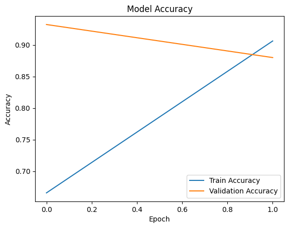

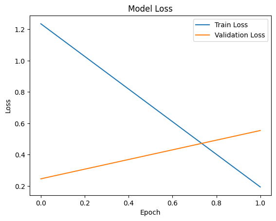

```python
print("Training History:")
print("Epochs:", history.epoch)
print("Train Loss:", history.history['loss'])
print("Train Accuracy:", history.history['accuracy'])
print("Validation Loss:", history.history['val_loss'])
print("Validation Accuracy:", history.history['val_accuracy'])

plt.plot(history.history['accuracy'], label='Train Accuracy')
plt.plot(history.history['val_accuracy'], label='Validation Accuracy')
plt.title('Model Accuracy')
plt.ylabel('Accuracy')
plt.xlabel('Epoch')
plt.legend()
plt.show()

plt.plot(history.history['loss'], label='Train Loss')
plt.plot(history.history['val_loss'], label='Validation Loss')
plt.title('Model Loss')
plt.ylabel('Loss')
plt.xlabel('Epoch')
plt.legend()
plt.show()
```

### Second CNN Model - A bit more complex model

```python
def create_complex_cnn_model():
    model = Sequential()

    model.add(Input(shape=(100, 100, 3)))

    # Conv 1
    model.add(Conv2D(32, (3, 3), activation='relu'))
    model.add(BatchNormalization())
    model.add(MaxPooling2D(pool_size=(2, 2)))

    # Conv 2
    model.add(Conv2D(64, (3, 3), activation='relu'))
    model.add(BatchNormalization())
    model.add(MaxPooling2D(pool_size=(2, 2)))

    # Conv 3
    model.add(Conv2D(128, (3, 3), activation='relu'))
    model.add(BatchNormalization())
    model.add(MaxPooling2D(pool_size=(2, 2)))

    # Conv 4
    model.add(Conv2D(256, (3, 3), activation='relu'))
    model.add(BatchNormalization())
    model.add(MaxPooling2D(pool_size=(2, 2)))

    # Global Average Pooling layer
    model.add(GlobalAveragePooling2D())

    # Fully Connected Layer
    model.add(Dense(128, activation='relu'))
    model.add(Dropout(0.5))
    model.add(Dense(141, activation='softmax'))

    return model

model = create_complex_cnn_model()

model.compile(optimizer='adam', loss='sparse_categorical_crossentropy', metrics=['accuracy'])

history = model.fit(
    train_generator,
    validation_data=validation_generator,
    epochs=2,
    steps_per_epoch=train_generator.samples // train_generator.batch_size,
    validation_steps=validation_generator.samples // validation_generator.batch_size
)
```

```
1763/1763 ━━━━━━━━━━━━━━━━━━━━ 508s 287ms/step - accuracy: 0.5345 - loss: 1.8620 - val_accuracy: 0.9278 - val_loss: 0.2040
1763/1763 ━━━━━━━━━━━━━━━━━━━━ 0s 55us/step - accuracy: 0.9375 - loss: 0.1136 - val_accuracy: 0.9600 - val_loss: 0.0747
```

```
Training History:
Epochs: [0, 1]
Train Loss: [0.916467547416687, 0.11355028301477432]
Train Accuracy: [0.7461524605751038, 0.9375]
Validation Loss: [0.20400367677211761, 0.07474441826343536]
Validation Accuracy: [0.9278017282485962, 0.9599999785423279]
```

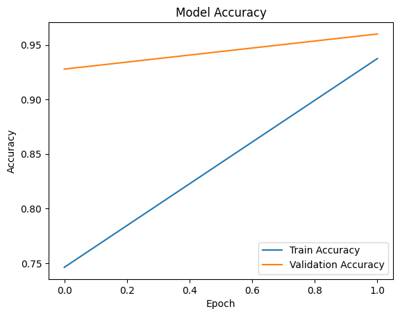

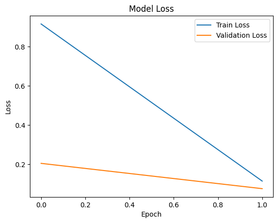

```python
# Print the training history
print("Training History:")
print("Epochs:", history.epoch)
print("Train Loss:", history.history['loss'])
print("Train Accuracy:", history.history['accuracy'])
print("Validation Loss:", history.history['val_loss'])
print("Validation Accuracy:", history.history['val_accuracy'])

# Plot the training history
plt.plot(history.history['accuracy'], label='Train Accuracy')
plt.plot(history.history['val_accuracy'], label='Validation Accuracy')
plt.title('Model Accuracy')
plt.ylabel('Accuracy')
plt.xlabel('Epoch')
plt.legend()
plt.show()

plt.plot(history.history['loss'], label='Train Loss')
plt.plot(history.history['val_loss'], label='Validation Loss')
plt.title('Model Loss')
plt.ylabel('Loss')
plt.xlabel('Epoch')
plt.legend()
plt.show()
```

### Fine tune hyper parameters

```python
def create_complex_cnn_model():
    model = Sequential()

    model.add(Input(shape=(100, 100, 3)))

    # Conv 1
    model.add(Conv2D(32, (3, 3), activation='relu'))
    model.add(BatchNormalization())
    model.add(MaxPooling2D(pool_size=(2, 2)))

    # Conv 2
    model.add(Conv2D(64, (3, 3), activation='relu'))
    model.add(BatchNormalization())
    model.add(MaxPooling2D(pool_size=(2, 2)))

    # Conv 3
    model.add(Conv2D(128, (4, 4), activation='relu')) # <-- Fine tuned this to (4, 4) instead of (3,3)
    model.add(BatchNormalization())
    model.add(MaxPooling2D(pool_size=(2, 2)))

    # Conv 4
    model.add(Conv2D(256, (5, 5), activation='relu')) # <-- Fine tuned this to (5, 5) instead of (3,3)
    model.add(BatchNormalization())
    model.add(MaxPooling2D(pool_size=(2, 2)))

    # Global Average Pooling layer
    model.add(GlobalAveragePooling2D())

    # FC Layer
    model.add(Dense(128, activation='relu'))
    model.add(Dropout(0.5))
    model.add(Dense(141, activation='softmax'))

    return model

model = create_complex_cnn_model()

model.compile(optimizer='adam', loss='sparse_categorical_crossentropy', metrics=['accuracy'])

history = model.fit(
    train_generator,
    validation_data=validation_generator,
    epochs=4,# <-- Fine tuned this to 4 epochs
    steps_per_epoch=train_generator.samples // train_generator.batch_size,
    validation_steps=validation_generator.samples // validation_generator.batch_size
)
```

```
1763/1763 ━━━━━━━━━━━━━━━━━━━━ 550s 311ms/step - accuracy: 0.5442 - loss: 1.8373 - val_accuracy: 0.9474 - val_loss: 0.1645
1763/1763 ━━━━━━━━━━━━━━━━━━━━ 0s 35us/step - accuracy: 0.8750 - loss: 0.3312 - val_accuracy: 0.9600 - val_loss: 0.1001
1763/1763 ━━━━━━━━━━━━━━━━━━━━ 541s 307ms/step - accuracy: 0.9534 - loss: 0.1520 - val_accuracy: 0.9218 - val_loss: 0.2317
1763/1763 ━━━━━━━━━━━━━━━━━━━━ 0s 31us/step - accuracy: 1.0000 - loss: 0.0939 - val_accuracy: 0.8800 - val_loss: 0.3205
```

```
2024-10-26 18:16:58.854981: I tensorflow/core/framework/local_rendezvous.cc:404] Local rendezvous is aborting with status: OUT_OF_RANGE: End of sequence
	 [[{{node IteratorGetNext}}]]
```

```
Training History:
Epochs: [0, 1, 2, 3]
Train Loss: [0.8783352971076965, 0.33119672536849976, 0.12945511937141418, 0.09393160045146942]
Train Accuracy: [0.7598049640655518, 0.875, 0.9600886702537537, 1.0]
Validation Loss: [0.1644735038280487, 0.10007620602846146, 0.2317105233669281, 0.32048970460891724]
Validation Accuracy: [0.9474138021469116, 0.9599999785423279, 0.9217672348022461, 0.8799999952316284]
```

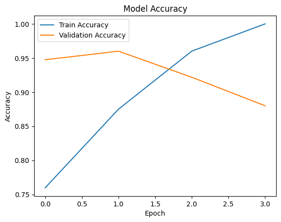

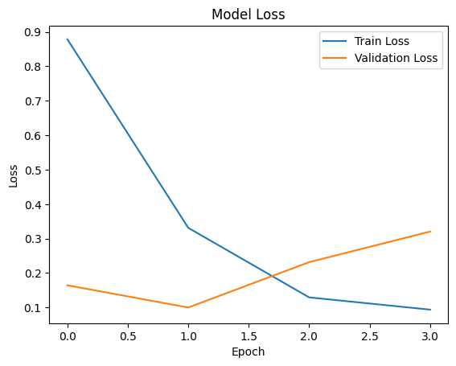

```python
print("Training History:")
print("Epochs:", history.epoch)
print("Train Loss:", history.history['loss'])
print("Train Accuracy:", history.history['accuracy'])
print("Validation Loss:", history.history['val_loss'])
print("Validation Accuracy:", history.history['val_accuracy'])

plt.plot(history.history['accuracy'], label='Train Accuracy')
plt.plot(history.history['val_accuracy'], label='Validation Accuracy')
plt.title('Model Accuracy')
plt.ylabel('Accuracy')
plt.xlabel('Epoch')
plt.legend()
plt.show()

plt.plot(history.history['loss'], label='Train Loss')
plt.plot(history.history['val_loss'], label='Validation Loss')
plt.title('Model Loss')
plt.ylabel('Loss')
plt.xlabel('Epoch')
plt.legend()
plt.show()
```

### Transfer Learning - Using MobileNetV2 Model

```python
base_model = MobileNetV2(weights='imagenet', include_top=False)

base_model.trainable = False

model = Sequential([
    base_model,
    GlobalAveragePooling2D(),
    Dense(128, activation='relu'),
    Dropout(0.5),
    Dense(141, activation='softmax')
])

model.compile(optimizer='adam', loss='sparse_categorical_crossentropy', metrics=['accuracy'])

history = model.fit(
    train_generator,
    validation_data=validation_generator,
    epochs=2,
    steps_per_epoch=train_generator.samples // train_generator.batch_size,
    validation_steps=validation_generator.samples // validation_generator.batch_size
)
```

```
1763/1763 ━━━━━━━━━━━━━━━━━━━━ 138s 77ms/step - accuracy: 0.5337 - loss: 1.9971 - val_accuracy: 0.9608 - val_loss: 0.1433
1763/1763 ━━━━━━━━━━━━━━━━━━━━ 0s 75us/step - accuracy: 0.8750 - loss: 0.5008 - val_accuracy: 1.0000 - val_loss: 0.0384
```

```
Training History:
Epochs: [0, 1]
Train Loss: [1.0039398670196533, 0.5007616281509399]
Train Accuracy: [0.7352127432823181, 0.875]
Validation Loss: [0.14330346882343292, 0.03844045475125313]
Validation Accuracy: [0.9607758522033691, 1.0]
```

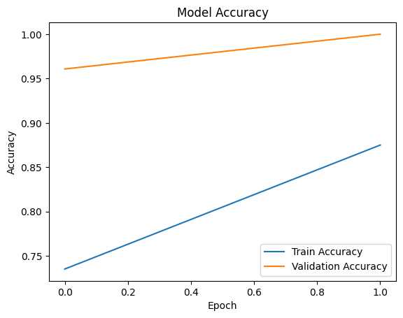

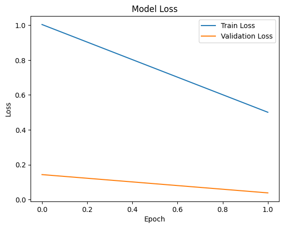

```python
print("Training History:")
print("Epochs:", history.epoch)
print("Train Loss:", history.history['loss'])
print("Train Accuracy:", history.history['accuracy'])
print("Validation Loss:", history.history['val_loss'])
print("Validation Accuracy:", history.history['val_accuracy'])

plt.plot(history.history['accuracy'], label='Train Accuracy')
plt.plot(history.history['val_accuracy'], label='Validation Accuracy')
plt.title('Model Accuracy')
plt.ylabel('Accuracy')
plt.xlabel('Epoch')
plt.legend()
plt.show()

plt.plot(history.history['loss'], label='Train Loss')
plt.plot(history.history['val_loss'], label='Validation Loss')
plt.title('Model Loss')
plt.ylabel('Loss')
plt.xlabel('Epoch')
plt.legend()
plt.show()
```

Fine tuning the model to run for 5 epochs

```python
base_model = MobileNetV2(weights='imagenet', include_top=False)

base_model.trainable = False

model = Sequential([
    base_model,
    GlobalAveragePooling2D(),
    Dense(128, activation='relu'),
    Dropout(0.5),
    Dense(141, activation='softmax')
])

model.compile(optimizer='adam', loss='sparse_categorical_crossentropy', metrics=['accuracy'])

history = model.fit(
    train_generator,
    validation_data=validation_generator,
    epochs=5,
    steps_per_epoch=train_generator.samples // train_generator.batch_size,
    validation_steps=validation_generator.samples // validation_generator.batch_size
)
```

```
1763/1763 ━━━━━━━━━━━━━━━━━━━━ 147s 82ms/step - accuracy: 0.5128 - loss: 2.0836 - val_accuracy: 0.9601 - val_loss: 0.1294
1763/1763 ━━━━━━━━━━━━━━━━━━━━ 0s 72us/step - accuracy: 0.9375 - loss: 0.1918 - val_accuracy: 0.9200 - val_loss: 0.2610
1763/1763 ━━━━━━━━━━━━━━━━━━━━ 143s 81ms/step - accuracy: 0.9069 - loss: 0.2897 - val_accuracy: 0.9649 - val_loss: 0.0889
1763/1763 ━━━━━━━━━━━━━━━━━━━━ 0s 52us/step - accuracy: 0.9375 - loss: 0.2117 - val_accuracy: 1.0000 - val_loss: 0.0526
1763/1763 ━━━━━━━━━━━━━━━━━━━━ 148s 84ms/step - accuracy: 0.9347 - loss: 0.1978 - val_accuracy: 0.9716 - val_loss: 0.0977
```

```
Training History:
Epochs: [0, 1, 2, 3, 4]
Train Loss: [1.065500259399414, 0.19182397425174713, 0.26241016387939453, 0.21174177527427673, 0.18702831864356995]
Train Accuracy: [0.7188652753829956, 0.9375, 0.9145744442939758, 0.9375, 0.9371808767318726]
Validation Loss: [0.12935946881771088, 0.2609517574310303, 0.08887920528650284, 0.05261155590415001, 0.09774378687143326]
Validation Accuracy: [0.9601293206214905, 0.9200000166893005, 0.9648706912994385, 1.0, 0.9715517163276672]
```

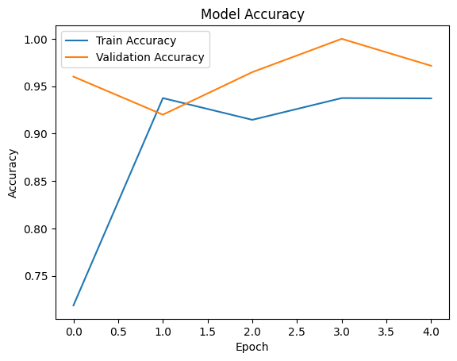

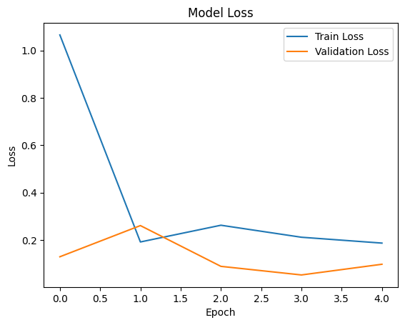

```python
print("Training History:")
print("Epochs:", history.epoch)
print("Train Loss:", history.history['loss'])
print("Train Accuracy:", history.history['accuracy'])
print("Validation Loss:", history.history['val_loss'])
print("Validation Accuracy:", history.history['val_accuracy'])

plt.plot(history.history['accuracy'], label='Train Accuracy')
plt.plot(history.history['val_accuracy'], label='Validation Accuracy')
plt.title('Model Accuracy')
plt.ylabel('Accuracy')
plt.xlabel('Epoch')
plt.legend()
plt.show()

plt.plot(history.history['loss'], label='Train Loss')
plt.plot(history.history['val_loss'], label='Validation Loss')
plt.title('Model Loss')
plt.ylabel('Loss')
plt.xlabel('Epoch')
plt.legend()
plt.show()
```

#### Predict some images!

And finally I will be picking up some images and will predict their labels

```python
dataset_path = 'fruits/fruits-360_dataset_100x100/fruits-360/Training'

class_names = os.listdir(dataset_path)
class_names.sort()

all_images = []
for class_name in class_names:
    class_path = os.path.join(dataset_path, class_name)
    images = os.listdir(class_path)
    for img in images:
        all_images.append((os.path.join(class_path, img), class_name))

random_images = random.sample(all_images, 10)

predictions = []
original_classes = []

for img_path, original_class in random_images:
    img = image.load_img(img_path, target_size=(100, 100))
    img_array = image.img_to_array(img) / 255.0
    img_array = np.expand_dims(img_array, axis=0)

    prediction = model.predict(img_array)
    predicted_class = np.argmax(prediction, axis=1)[0]

    predictions.append(predicted_class)
    original_classes.append(original_class)

for i in range(len(predictions)):
    print(f"Original Class: {original_classes[i]}, Predicted Class: {class_names[predictions[i]]}")
```

```
1/1 ━━━━━━━━━━━━━━━━━━━━ 1s 709ms/step
1/1 ━━━━━━━━━━━━━━━━━━━━ 0s 20ms/step
1/1 ━━━━━━━━━━━━━━━━━━━━ 0s 20ms/step
1/1 ━━━━━━━━━━━━━━━━━━━━ 0s 18ms/step
1/1 ━━━━━━━━━━━━━━━━━━━━ 0s 19ms/step
1/1 ━━━━━━━━━━━━━━━━━━━━ 0s 19ms/step
1/1 ━━━━━━━━━━━━━━━━━━━━ 0s 19ms/step
1/1 ━━━━━━━━━━━━━━━━━━━━ 0s 18ms/step
1/1 ━━━━━━━━━━━━━━━━━━━━ 0s 18ms/step
1/1 ━━━━━━━━━━━━━━━━━━━━ 0s 19ms/step
Original Class: Kaki 1, Predicted Class: Kaki 1
Original Class: Cherry 2, Predicted Class: Cherry 2
Original Class: Avocado ripe 1, Predicted Class: Avocado ripe 1
Original Class: Tomato Heart 1, Predicted Class: Tomato Heart 1
Original Class: Fig 1, Predicted Class: Fig 1
Original Class: Physalis 1, Predicted Class: Physalis 1
Original Class: Mango 1, Predicted Class: Mango 1
Original Class: Cherry 1, Predicted Class: Cherry 1
Original Class: Nut Forest 1, Predicted Class: Nut Forest 1
Original Class: Raspberry 1, Predicted Class: Raspberry 1
```

# Summary

Summary and closing thoughts

In this project, I worked on the Fruits-360 dataset, a comprehensive collection of over 94,000 images of various fruits, vegetables, and nuts, designed to facilitate research in computer vision and machine learning. The dataset has 141 distinct classes and it's divided into a training set of 70,491 images and a test set of 23,619 images.

- EDA

  I performed exploratory data analysis (EDA) on the dataset, which included distribution of classes and visualize the images.
- Model Development

  I built and evaluated three convolutional neural network (CNN) models, along with one transfer learning model, to classify the different fruites in the dataset.

**Basic CNN Model:**

```
Created a straightforward CNN architecture with three convolutional layers, each followed by max pooling and ended with a fully connected layer. The model was trained for 2 epochs.
```

**Complex CNN Model:**

```
Then I developed a more complex CNN that uses batch normalization and an additional convolutional block, which enhanced the model’s ability to learn from the data.
```

**Fine-Tuned CNN Model:**

```
Then I started fine tuning the complex CNN model by adjusting hyperparameters, which included changing some of the kernel sizes in the convolutional blocks, and I increased the training epochs to 4.
```

Transfer Learning with MobileNetV2:

**Transfer Learning**

```
And finally I have Leveraged transfer learning by utilizing the MobileNetV2 architecture as a base model, freezed its wegihts, and added custom layers for classification part. This model was also trained for 2 epochs.
```

**Future work and enhancements**

```
Finally I'd like to close this section by what can be done to enhance the work I've done, this includes:
- Add much more complex model and much simpler models and compare them for the best results
- Fine tune more hyper parameters
- Utilize bigger and fancier models for transfer learning
```

# References

https://www.kaggle.com/datasets/moltean/fruits/data

https://www.tensorflow.org/api_docs

https://www.tensorflow.org/api_docs/python/tf/keras/preprocessing/image/ImageDataGenerator

# Citation

Mihai Oltean, Fruits-360 dataset, 2017-